# 02 Progresión Geométrica

2024-01-15

## Tema 1: Progresiones y series

- **Series**: Es una secuencia de valores que se suman o restan para obtener un valor final.
- **Progresión aritmética**: La diferencia común entre los términos consecutivos es constante y sigue una secuencia numérica ordenada.
- **Progresión geométrica**: cada término se obtiene multiplicando el término anterior por una constante.

## Tema 1.1 Series

**Serie**

Supongamos que tienes una cuenta de ahorros.

\(\begin{align*} a_1 &= 100 \quad \text{(depósito inicial)} \\ a_2 &= 50 \quad \text{(depósito adicional en el segundo mes)} \\ a_3 &= 30 \quad \text{(retiro en el tercer mes)} \\ a_4 &= 20 \quad \text{(retiro en el cuarto mes)} \end{align*}\)

## Tema 1.1 Series

**Serie**  
La serie expresada como una operación:  
\(a_1 + a_2 - a_3 - a_4\)

Sustituyendo los valores:  
\(100 + 50 - 30 - 20 = 100\)

## Tema 1.1 Progresión Geométrica (1)

- El crudo de esta está disminuyendo un 10 % cada año.
- Dado que las reservas iniciales Shell son 100,000 millones de litros.
- Demuestra que las reservas de petróleo crudo siguen una secuencia geométrica decreciente.
- Encuentra la razón común para ello.

## Tema 1.1 Progresión Geométrica (1)

\(r=1-.10=.9\)

\(S_0 = 100 000\)

\(S_1 = S_0*0.9\)

\(S_2 = S_1*0.9\)

\(S_2 = S_0*0.9*0.9\)

\(S_2 = 100000*0.9^2\)

## Tema 1.1 Progresión Geométrica (1)

\(S_n = S_0*r^n\)

-¿Cuál sería el valor en 4 años? \(S_4 = 100 000*.9^4=65610\)

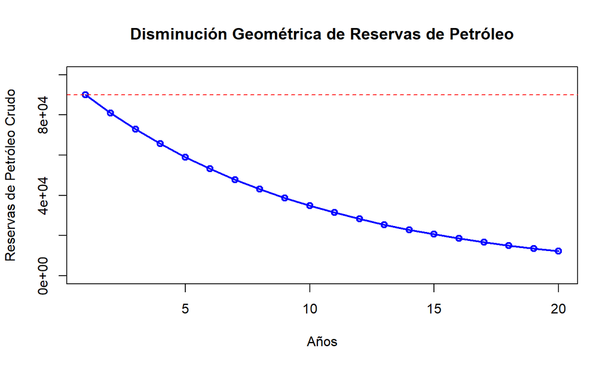

## Tema 1.1 Progresión Geométrica (2)

- Las acciones de una empresa se emiten inicialmente a un precio de 100 USD.
- El valor de las acciones aumenta en un 25 % cada año.
- Demuestra que las acciones de una empresa siguen una secuencia geométrica creciente.
- Encuentra la razón común para ello.
- ¿Qué precio tendrá en 15 años?

## Tema 1.1 Progresión Geométrica (2)

\(r=1+.25=1.25\)

\(S_0 = 100\)

\(S_1 = S_0*1.25\)

\(S_2 = S_1*1.25\)

\(S_2 = S_0*1.25*1.25\)

\(S_n = S_0*r^{n}\)

En 15 años: \(100*1.25^15 = 2842.17\)

## Tema 1.1 Progresión Geométrica (2)

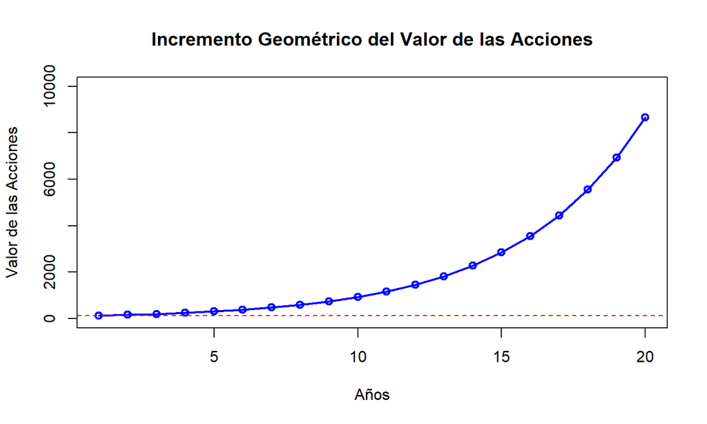

## Tema 1.1 Progresión Geométrica (3)

\(S4=S_0*2*2*2=S_0*2^3\)

## Tema 1.1 Progresión Geométrica (3)

\(S_n=S1*2^n\)

## Tema 1.1 Progresión Geométrica (4)

- Marco invierte \(2000\) USD en esta cuenta de inversión.
- Cada año crece su inversión al \(2\)%.
- Durante esos 5 años, hubo una inflación del 2.5% anual.
- Tasa de interés anual \(r=0.02\)
- Tasa de inflación anual \(i=0.025\)
- El cambio porcentual anual en términos reales es:

\(p = r - i=-0.005=-0.5\%\)

## Tema 1.1 Progresión Geométrica (4)

- Una reducción del \(-0.5\%\) es equivalente a \(S_1*(1 - 0.005)\)

\(S_0 = 2000\)

\(S_1 = S_0*0.995\)

\(S_2 = S_1*0.995\)

\(S_2 = S_0*0.995*0.995\)

\(S_2 = 2000*0.995^2\)

Se generaliza: \(S_n = S_0p^n\)

\(S_5= 2000*0.995^5 = 1950.50\)

## Tema 1.1 Progresión Geométrica (5)

- Imagina que esta serie representa la deuda anual de una persona en miles de pesos: $2, 6, 18, 54,$

Deduce la serie geométrica y calcula la deuda en el año 7.

## Tema 1.1 Progresión Geométrica (5)

\(S_0=2\)

\(S_1=S_0*3=6\)

\(S_2=S_1*3=18\)

\(S_2=S_0*3*3=18\)

\(S_2=2*3*3=18\)

\(S_2=2*3^2=18\)

## Tema 1.1 Progresión Geométrica (5)

Se generaliza: \(S_n=2*3^n\)

\(S_7=2*3^7=4374\)

## Tema 1.1 Progresión Geométrica (6)

Imagina que esta serie representa el costo anual de la matrícula universitaria de un estudiante en miles de pesos:

\(5,10,20,40,\dots\)

Deduce la serie geométrica y calcula el costo en el año 6.

\(T_0=5\)

\(T_1=T_0*2=10\)

\(T_2=T_1*2=20\)

\(T_2=T_0*2*2=20\)

\(T_2=5*2*2=20\)

\(T_2=5*2^2=20\)

## Tema 1.2 Progresión Geométrica (5)

Se generaliza: \(T_n=5*2^n\)

\(T_6=5*2^6=320\)

## Tema 1.2 Progresión Geométrica (6)

- Imagina que esta serie representa el valor de un terreno que se aprecia en un 10% cada año.
- El valor inicial del terreno es de \(50000\) USD.

Demuestra que el valor del terreno sigue una secuencia geométrica creciente. Encuentra la razón común para ello. ¿Cuál será el valor del terreno en 10 años?

## Tema 1.2 Progresión Geométrica (6)

\(r=1+.10=1.10\)

\(T_0 = 50000\)

\(T_1 = T_0*1.10\)

\(T_2 = T_1*1.10\)

\(T_2 = T_0*1.10*1.10\)

\(T_n = T_0*r^{n}\)

En 10 años: \(50000*1.10^10 = 129687.01\)

## Tema 1.2 Progresión Geométrica (7)

- Laura invierte 3000 USD en una cuenta de inversión.
- Cada año, su inversión crece al 3%.
- Durante esos 6 años, hay una inflación del 2.8% anual.
- Tasa de interés anual \(j=0.03\)
- Tasa de inflación anual \(i=0.028\)

El cambio porcentual anual en términos reales es

## Tema 1.2 Progresión Geométrica (7)

\(r=j−i=0.002=0.2%\)

- Un aumento del \(0.2\%\) es equivalente a \(T_1*(1 + 0.002)\)

\(T_0 = 3000\)

\(T_1 = T_0*1.002\)

\(T_2 = T_1*1.002\)

\(T_2 = T_0*1.002*1.002\)

\(T_2 = 3000*1.002^2\)

Se generaliza: \(T_n = T_0p^n\)

\(T_6= 3000*1.002^6 =3036.18\)

## Tema 1.2 Progresión Geométrica (8)

- Comprueba que esta serie de inversión sigue una serie geométrica: \(3.5, 24.5, 171.5, 1200.5\)

## Tema 1.2 Progresión Geométrica (8)

- Se puede ver que \(24.5\) es \(7\) veces el primer término \(I_0=3.5\), y
- El tercer término \(171.5\) es \(7\) veces el segundo término \(S_1=24.5\), que es \(7\) veces el primer término \(S_0=3.5\).

-Por lo tanto,

\(S_2=S_0*7*7=S_0*7^2\)

- Se generaliza se describe como:

\(S_n=S_0*7^n\)

## Revisión

## Revisión

```
## Versión: 22/01/2024
```

## Bibliografía

## Bibliografía

- Petters, A. O., & Dong, X. (2016). An introduction to mathematical finance with applications. New York, NY: Springer, 10,978-1.